# Module 162

#### Hemi-module gene counts:

352 probesets in hemi-module A.  
48 probesets in hemi-module B.  
Note: While the mapping of probesets to genes is usually one-to-one, some genes are targeted by multiple probesets, some probesets target multiple genes, and some probesets do not target any genes (i.e., the region of the genome they match is no longer considered genic).

#### Contrast SVE:

Signed variance explained (SVE) provides an indication of how similar a set of fold changes are to a gene module’s weight vector. An SVE value of 0.3, for example, indicates that 30% of the variance explained by the entire module set is accounted for by the module in question. Shown here are the SVE values for this module across a compendium of fold changes (contrasts). Extreme SVE values (e.g., > 0.05) indicate that those contrasts specifically induce (orange dots) or specifically repress (blue dots) this module. Examining the experimental conditions being compared in such contrasts (see tables below the figure) may provide insight into the gene module’s function.

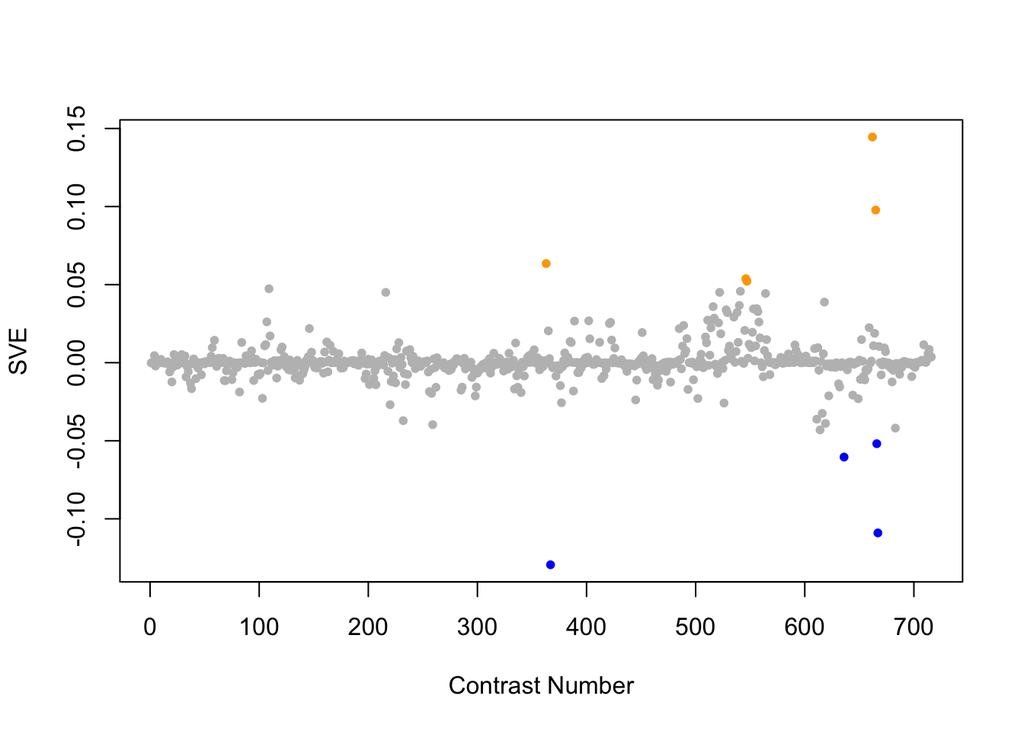

Positive SVE Contrasts:

|  | Contrast.Num | SVE | GEO.GSE | Cond.1 | Cond.2 | Mutation |
| --- | --- | --- | --- | --- | --- | --- |
| GSE15159.s2t1.vs.s0t1 | 662 | 0.14 | GSE15159 | xpa-1_control_2007_rep1 | N2_control_2007_rep1 | xpa-1 |
| GSE15159.s1t2.vs.s1t1 | 665 | 0.10 | GSE15159 | glp-1_UV_2007_rep1 | glp-1_control_2007_rep1 |  |
| GSE36358.s2t1.vs.s0t1 | 363 | 0.06 | GSE36358 | Clino Rotation | Ground Control (Tsukuba space center) |  |
| GSE2180.s3t3.vs.s1t3 | 546 | 0.05 | GSE2180 | p41-2 | 41D | pie-1(zu154) |
| GSE2180.s4t3.vs.s1t3 | 547 | 0.05 | GSE2180 | pp41-1 | 41D | pie-1(zu154);pal-1(RNAi) |

Negative SVE Contrasts:

|  | Contrast.Num | SVE | GEO.GSE | Cond.1 | Cond.2 | Mutation |
| --- | --- | --- | --- | --- | --- | --- |
| GSE35360A.s1t1.vs.s0t1 | 367 | -0.13 | GSE35360 | HF 11d_0.2_rep1 | HF 11d control_rep1 |  |
| GSE15159.s2t2.vs.s2t1 | 667 | -0.11 | GSE15159 | xpa-1_UV_2007_rep1 | xpa-1_control_2007_rep1 |  |
| GSE18132.s2t2.vs.s0t2 | 636 | -0.06 | GSE18132 | Oga Fed L4, biological replicate 1 | WT Fed L4, biological rep1 | oga-1 |
| GSE15159.s0t2.vs.s0t1 | 666 | -0.05 | GSE15159 | N2_UV_2007_rep1 | N2_control_2007_rep1 |  |
| GSE21591.s2t1.vs.s4t1 | 614 | -0.04 | GSE21591 | Input_1 | aMYC_1 |  |

$~$

#### Contrast SVE, Up-Regulated Genes Only:

Calculating SVE for up-regulated and down-regulated genes separately may be more informative in many cases than projecting the up- and down- gene sets together. This is due to the fact that the weight distribution of many modules is highly skewed, indicating that only one of the hemi-modules may be biologically meaningful (i.e., a set of genes are strongly correlated by only a few genes (or none) are strongly anti-correlated to that set.)

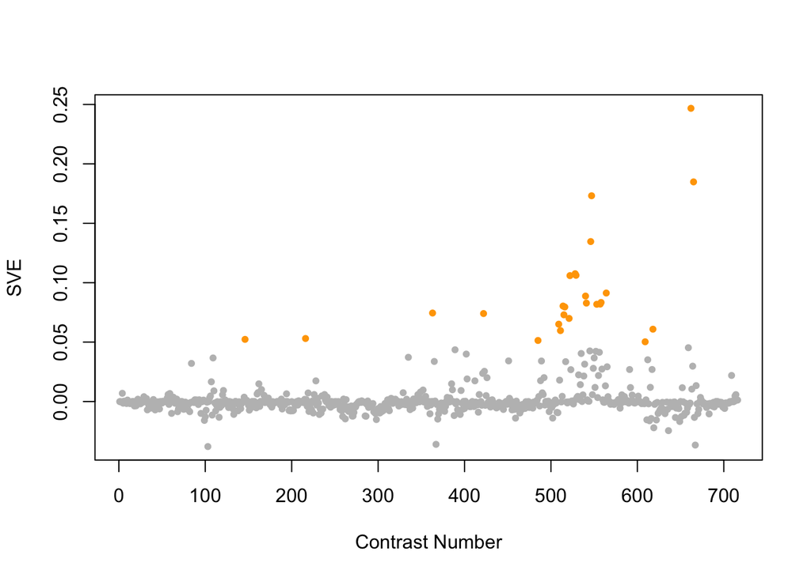

Positive SVE Contrasts:

|  | Contrast.Num | SVE | GEO.GSE | Cond.1 | Cond.2 | Mutation |
| --- | --- | --- | --- | --- | --- | --- |
| GSE15159.s2t1.vs.s0t1 | 662 | 0.25 | GSE15159 | xpa-1_control_2007_rep1 | N2_control_2007_rep1 | xpa-1 |
| GSE15159.s1t2.vs.s1t1 | 665 | 0.18 | GSE15159 | glp-1_UV_2007_rep1 | glp-1_control_2007_rep1 |  |
| GSE2180.s4t3.vs.s1t3 | 547 | 0.17 | GSE2180 | pp41-1 | 41D | pie-1(zu154);pal-1(RNAi) |
| GSE2180.s3t3.vs.s1t3 | 546 | 0.13 | GSE2180 | p41-2 | 41D | pie-1(zu154) |
| GSE2180.s3t9.vs.s1t9 | 528 | 0.11 | GSE2180 | p143-2 | 143L | pie-1(zu154) |
| GSE2180.s4t9.vs.s1t9 | 529 | 0.11 | GSE2180 | pp143-1 | 143L | pie-1(zu154);pal-1(RNAi) |
| GSE2180.s3t8.vs.s1t8 | 522 | 0.11 | GSE2180 | p122-2 | 122-1 | pie-1(zu154) |
| GSE2180.s3t6.vs.s1t6 | 564 | 0.09 | GSE2180 | p83-2 | 83-1 | pie-1(zu154) |
| GSE2180.s3t2.vs.s1t2 | 540 | 0.09 | GSE2180 | p23-2 | 23-1 | pie-1(zu154) |
| GSE2180.s3t5.vs.s1t5 | 558 | 0.08 | GSE2180 | p66-1 | 66-4 | pie-1(zu154) |
| GSE2180.s4t2.vs.s1t2 | 541 | 0.08 | GSE2180 | pp23-1 | 23-1 | pie-1(zu154);pal-1(RNAi) |
| GSE2180.s2t5.vs.s1t5 | 557 | 0.08 | GSE2180 | ms66-3 | 66-4 | mex-3(zu155);skn-1(RNAi) |
| GSE2180.s4t4.vs.s1t4 | 553 | 0.08 | GSE2180 | pp53-1 | 53-1 | pie-1(zu154);pal-1(RNAi) |
| GSE2180.s4t1.vs.s3t1 | 514 | 0.08 | GSE2180 | pp0-1 | p0-3 | pal-1(RNAi) |
| GSE2180.s3t7.vs.s1t7 | 516 | 0.08 | GSE2180 | p101-2 | 101G | pie-1(zu154) |
| GSE36358.s2t1.vs.s0t1 | 363 | 0.07 | GSE36358 | Clino Rotation | Ground Control (Tsukuba space center) |  |
| GSE28494.s1t2.vs.s1t1 | 422 | 0.07 | GSE28494 | lin-54(n3423) dissected germline 1 | lin-54(n2990) embryo 1 |  |
| GSE2180.s2t7.vs.s1t7 | 515 | 0.07 | GSE2180 | ms101-2 | 101G | mex-3(zu155);skn-1(RNAi) |
| GSE2180.s2t8.vs.s1t8 | 521 | 0.07 | GSE2180 | ms122-1 | 122-1 | mex-3(zu155);skn-1(RNAi) |
| GSE2180.s2t1.vs.s1t1 | 509 | 0.07 | GSE2180 | ms0-1 | 00B | mex-3(zu155);skn-1(RNAi) |
| GSE21591.s1t1.vs.s2t1 | 618 | 0.06 | GSE21591 | N2_aFLAG_1 | Input_1 |  |
| GSE2180.s4t1.vs.s1t1 | 511 | 0.06 | GSE2180 | pp0-1 | 00B | pie-1(zu154);pal-1(RNAi) |
| GSE42592A.s1t2.vs.s0t2 | 216 | 0.05 | GSE42592 | acrylamide_low_expose-4h_rep1 | acrylamide_control_expose-4h_rep1 |  |
| GSE50513.s4t1.vs.s2t1 | 146 | 0.05 | GSE50513 | zip-2 PA14 - rep 1 | L4440 PA14 - rep 1 | zip-2 |
| GSE23528A.s0t5.vs.s0t1 | 485 | 0.05 | GSE23528 | Adult at T18, non-entrained control time-series experiment 4 | Adult at T2, non-entrained control time-series experiment 4 |  |
| GSE21591.s4t1.vs.s5t1 | 609 | 0.05 | GSE21591 | aMYC_1 | aFLAG_1 |  |

Negative SVE Contrasts:

|  | Contrast.Num | SVE | GEO.GSE | Cond.1 | Cond.2 | Mutation |
| --- | --- | --- | --- | --- | --- | --- |
| GSE5793.s3t2.vs.s3t1 | 103 | -0.04 | GSE5793 | Celegans_PA14_8hours_RepA | Celegans_PA14_4hours_RepA |  |
| GSE15159.s2t2.vs.s2t1 | 667 | -0.04 | GSE15159 | xpa-1_UV_2007_rep1 | xpa-1_control_2007_rep1 |  |
| GSE35360A.s1t1.vs.s0t1 | 367 | -0.04 | GSE35360 | HF 11d_0.2_rep1 | HF 11d control_rep1 |  |
| GSE18132.s2t2.vs.s0t2 | 636 | -0.02 | GSE18132 | Oga Fed L4, biological replicate 1 | WT Fed L4, biological rep1 | oga-1 |
| GSE21467.s1t1.vs.s0t1 | 619 | -0.02 | GSE21467 | ung-1, biological rep1 | wild type N2, biological rep1 | ung-1 |

$~$

#### Contrast SVE, Down-Regulated Genes Only:

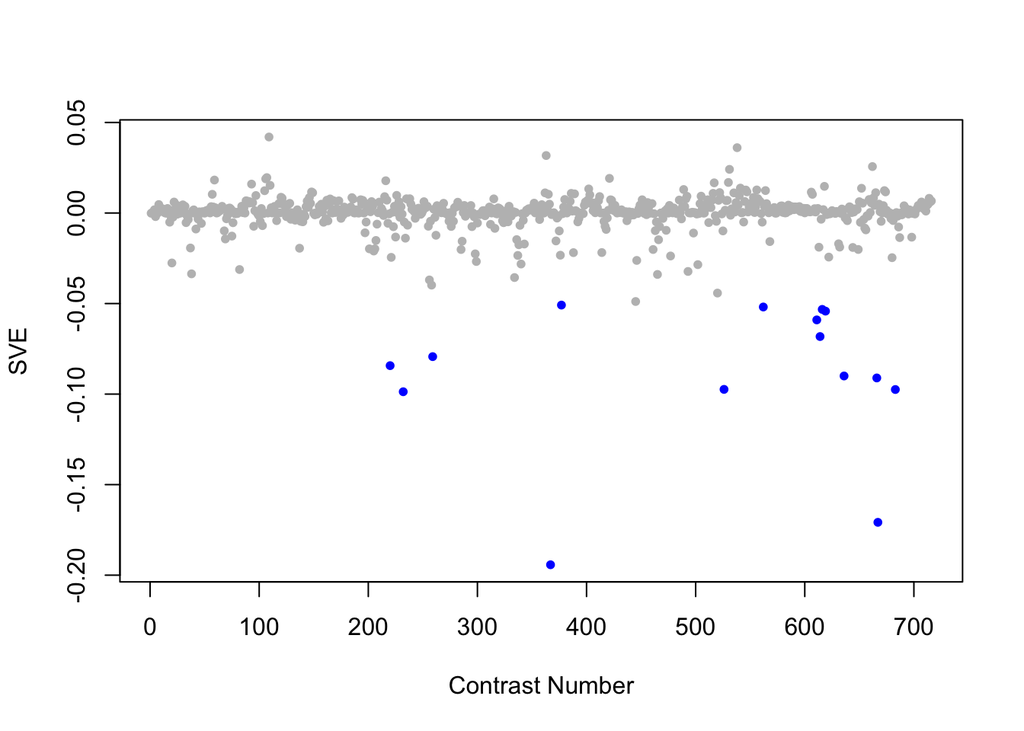

Positive SVE Contrasts:

|  | Contrast.Num | SVE | GEO.GSE | Cond.1 | Cond.2 | Mutation |
| --- | --- | --- | --- | --- | --- | --- |
| GSE54513.s4t1.vs.s2t1 | 109 | 0.04 | GSE54513 | spe-9 OMA-1 IP rep1 | fog-1 OMA-1 IP rep1 |  |
| GSE2180.s4t10.vs.s3t10 | 538 | 0.04 | GSE2180 | pp186-1 | p186-2 | pal-1(RNAi) |
| GSE36358.s2t1.vs.s0t1 | 363 | 0.03 | GSE36358 | Clino Rotation | Ground Control (Tsukuba space center) |  |
| GSE15159.s2t1.vs.s0t1 | 662 | 0.03 | GSE15159 | xpa-1_control_2007_rep1 | N2_control_2007_rep1 | xpa-1 |
| GSE2180.s4t9.vs.s2t9 | 531 | 0.02 | GSE2180 | pp143-1 | ms143-2 |  |

Negative SVE Contrasts:

|  | Contrast.Num | SVE | GEO.GSE | Cond.1 | Cond.2 | Mutation |
| --- | --- | --- | --- | --- | --- | --- |
| GSE35360A.s1t1.vs.s0t1 | 367 | -0.19 | GSE35360 | HF 11d_0.2_rep1 | HF 11d control_rep1 |  |
| GSE15159.s2t2.vs.s2t1 | 667 | -0.17 | GSE15159 | xpa-1_UV_2007_rep1 | xpa-1_control_2007_rep1 |  |
| GSE42592B.s0t2.vs.s0t1 | 232 | -0.10 | GSE42592 | cadmium_control_expose-4h_rep1 | cadmium_control_expose-0h_rep1 |  |
| GSE12298B.s1t1.vs.s0t1 | 683 | -0.10 | GSE12298 | fenamiphos_low_dose-rep1 | fenamiphos_control-rep1 |  |
| GSE2180.s4t8.vs.s3t8 | 526 | -0.10 | GSE2180 | pp122-1 | p122-2 | pal-1(RNAi) |
| GSE15159.s0t2.vs.s0t1 | 666 | -0.09 | GSE15159 | N2_UV_2007_rep1 | N2_control_2007_rep1 |  |
| GSE18132.s2t2.vs.s0t2 | 636 | -0.09 | GSE18132 | Oga Fed L4, biological replicate 1 | WT Fed L4, biological rep1 | oga-1 |
| GSE42592A.s2t3.vs.s0t3 | 220 | -0.08 | GSE42592 | acrylamide_mid_expose-8h_rep1 | acrylamide_control_expose-8h_rep1 |  |
| GSE41366A.s1t3.vs.s0t3 | 259 | -0.08 | GSE41366 | low_DDVP-2h_expose-20h_harvest-rep1 | control-2h_expose-20h_harvest-rep1 |  |
| GSE21591.s2t1.vs.s4t1 | 614 | -0.07 | GSE21591 | Input_1 | aMYC_1 |  |
| GSE21591.s2t1.vs.s5t1 | 611 | -0.06 | GSE21591 | Input_1 | aFLAG_1 |  |
| GSE21467.s1t1.vs.s0t1 | 619 | -0.05 | GSE21467 | ung-1, biological rep1 | wild type N2, biological rep1 | ung-1 |
| GSE21591.s2t1.vs.s3t1 | 616 | -0.05 | GSE21591 | Input_1 | GGF_aFLAG_1 |  |
| GSE2180.s4t5.vs.s3t5 | 562 | -0.05 | GSE2180 | pp66-1 | p66-1 | pal-1(RNAi) |
| GSE35354B.s1t3.vs.s1t1 | 377 | -0.05 | GSE35354 | TA200_rep1 | TA Control_rep1 |  |

$~$

$~$

#### GO Term Enrichment:

This analysis tests each hemi-module for enrichment of specific GO terms. Only gene-level annotations (e.g., as would be found on the gene’s page in Wormbase) are tested - the hierarchical structure of the GO ontology is not taken into account.

*Note: At least the top two most enriched terms from each GO domain (BP/MF/CC) are shown, even when not statistically significant.*

##### Enriched GO terms: Hemi-module A

| ID | GO.Term | GO Domain | Raw p-value | Adj p-value |
| --- | --- | --- | --- | --- |
| [GO_0007186](http://amigo.geneontology.org/amigo/term/GO:0007186) | G protein-coupled receptor signaling pathway | BP | 2.98e-25 | 1.09e-21 |
| [GO_0050911](http://amigo.geneontology.org/amigo/term/GO:0050911) | detection of chemical stimulus involved in sensory perception of smell | BP | 2.97e-21 | 5.41e-18 |
| [GO_0042048](http://amigo.geneontology.org/amigo/term/GO:0042048) | olfactory behavior | BP | 2.03e-19 | 2.46e-16 |
| [GO_0007606](http://amigo.geneontology.org/amigo/term/GO:0007606) | sensory perception of chemical stimulus | BP | 1.10e-09 | 1.00e-06 |
| [GO_0055114](http://amigo.geneontology.org/amigo/term/GO:0055114) | oxidation-reduction process | BP | 1.09e-05 | 7.91e-03 |
| [GO_0038022](http://amigo.geneontology.org/amigo/term/GO:0038022) | G protein-coupled olfactory receptor activity | MF | 1.23e-20 | 2.51e-17 |
| [GO_0046872](http://amigo.geneontology.org/amigo/term/GO:0046872) | metal ion binding | MF | 2.39e-08 | 2.44e-05 |
| [GO_0016740](http://amigo.geneontology.org/amigo/term/GO:0016740) | transferase activity | MF | 4.11e-07 | 2.20e-04 |
| [GO_0005515](http://amigo.geneontology.org/amigo/term/GO:0005515) | protein binding | MF | 5.32e-07 | 2.20e-04 |
| [GO_0016787](http://amigo.geneontology.org/amigo/term/GO:0016787) | hydrolase activity | MF | 5.40e-07 | 2.20e-04 |
| [GO_0005524](http://amigo.geneontology.org/amigo/term/GO:0005524) | ATP binding | MF | 8.30e-07 | 2.83e-04 |
| [GO_0000166](http://amigo.geneontology.org/amigo/term/GO:0000166) | nucleotide binding | MF | 9.84e-07 | 2.87e-04 |
| [GO_0008528](http://amigo.geneontology.org/amigo/term/GO:0008528) | G protein-coupled peptide receptor activity | MF | 2.51e-05 | 6.41e-03 |
| [GO_0004930](http://amigo.geneontology.org/amigo/term/GO:0004930) | G protein-coupled receptor activity | MF | 4.35e-05 | 9.88e-03 |
| [GO_0004888](http://amigo.geneontology.org/amigo/term/GO:0004888) | transmembrane signaling receptor activity | MF | 8.41e-05 | 1.72e-02 |
| [GO_0003723](http://amigo.geneontology.org/amigo/term/GO:0003723) | RNA binding | MF | 1.40e-04 | 2.59e-02 |
| [GO_0016491](http://amigo.geneontology.org/amigo/term/GO:0016491) | oxidoreductase activity | MF | 2.51e-04 | 4.28e-02 |
| [GO_0003677](http://amigo.geneontology.org/amigo/term/GO:0003677) | DNA binding | MF | 3.47e-04 | 5.46e-02 |
| [GO_0016021](http://amigo.geneontology.org/amigo/term/GO:0016021) | integral component of membrane | CC | 6.00e-81 | 5.57e-78 |
| [GO_0016020](http://amigo.geneontology.org/amigo/term/GO:0016020) | membrane | CC | 9.13e-76 | 4.24e-73 |
| [GO_0005634](http://amigo.geneontology.org/amigo/term/GO:0005634) | nucleus | CC | 1.35e-13 | 4.19e-11 |
| [GO_0005737](http://amigo.geneontology.org/amigo/term/GO:0005737) | cytoplasm | CC | 5.68e-13 | 1.32e-10 |
| [GO_0005887](http://amigo.geneontology.org/amigo/term/GO:0005887) | integral component of plasma membrane | CC | 2.65e-11 | 4.91e-09 |
| [GO_0005739](http://amigo.geneontology.org/amigo/term/GO:0005739) | mitochondrion | CC | 2.26e-05 | 3.49e-03 |
| [GO_0005829](http://amigo.geneontology.org/amigo/term/GO:0005829) | cytosol | CC | 8.86e-05 | 1.17e-02 |

##### Enriched GO terms: Hemi-module B

| ID | GO.Term | GO Domain | Raw p-value | Adj p-value |
| --- | --- | --- | --- | --- |
| [GO_0007368](http://amigo.geneontology.org/amigo/term/GO:0007368) | determination of left/right symmetry | BP | 2.08e-03 | 1.00e+00 |
| [GO_0003388](http://amigo.geneontology.org/amigo/term/GO:0003388) | neuron development involved in amphid sensory organ development | BP | 4.15e-03 | 1.00e+00 |
| [GO_0042302](http://amigo.geneontology.org/amigo/term/GO:0042302) | structural constituent of cuticle | MF | 1.46e-04 | 2.99e-01 |
| [GO_0008420](http://amigo.geneontology.org/amigo/term/GO:0008420) | RNA polymerase II CTD heptapeptide repeat phosphatase activity | MF | 8.29e-03 | 1.00e+00 |
| [GO_0005813](http://amigo.geneontology.org/amigo/term/GO:0005813) | centrosome | CC | 4.13e-04 | 3.83e-01 |
| [GO_0005581](http://amigo.geneontology.org/amigo/term/GO:0005581) | collagen trimer | CC | 6.17e-03 | 1.00e+00 |

$~$

$~$

#### Tissue Enrichment:

This analysis tests each hemi-module for enrichment of genes associated with anatomy terms. Negative enrichment scores indicate fewer hemi-module genes than expected by random chance were associated with the anatomy term in question.

##### Enriched tissues: Hemi-module A

| ID | Anatomy.Term | Definition | Raw p-value | Adj p-value |
| --- | --- | --- | --- | --- |
| [WBbt_0003887](https://wormbase.org/species/all/anatomy_term/WBbt:0003887) | ASIR | one member of Amphid neurons, single ciliated endings, probably chemo-sensory; project into ring via commissure from ventral ganglion, make diverse synaptic connections in ring neuropil | 1.78e-10 | 2.17e-07 |
| [WBbt_0003888](https://wormbase.org/species/all/anatomy_term/WBbt:0003888) | ASIL | one member of amphid neurons, single ciliated ending, probably chemo-sensory; project into ring via commissure from ventral ganglion, make diverse synaptic connections in ring neuropil | 1.78e-10 | 2.17e-07 |
| [WBbt_0003995](https://wormbase.org/species/all/anatomy_term/WBbt:0003995) | ADLR | Amphid neuron, prob. chemosensory | 2.42e-07 | 1.47e-04 |
| [WBbt_0003997](https://wormbase.org/species/all/anatomy_term/WBbt:0003997) | ADLL | Amphid neuron, prob. chemosensory | 2.42e-07 | 1.47e-04 |
| [WBbt_0004070](https://wormbase.org/species/all/anatomy_term/WBbt:0004070) | PVT | Neuron class of one interneuron, projects along ventral cord to ring. | 4.45e-07 | 2.17e-04 |
| [WBbt_0003885](https://wormbase.org/species/all/anatomy_term/WBbt:0003885) | ASJR | one member of Amphid neurons, single ciliated endings, probably chemo-sensory; project into ring via commissure from ventral ganglion, make diverse synaptic connections in ring neuropil | 2.86e-05 | 1.02e-02 |
| [WBbt_0003886](https://wormbase.org/species/all/anatomy_term/WBbt:0003886) | ASJL | one member of Amphid neurons, single ciliated endings, probably chemo-sensory; project into ring via commissure from ventral ganglion, make diverse synaptic connections in ring neuropil | 3.31e-05 | 1.02e-02 |
| [WBbt_0003889](https://wormbase.org/species/all/anatomy_term/WBbt:0003889) | ASHR | one member of Amphid neurons, single ciliated endings, probably chemo-sensory; project into ring via commissure from ventral ganglion, make diverse synaptic connections in ring neuropil | 3.55e-05 | 1.02e-02 |
| [WBbt_0003890](https://wormbase.org/species/all/anatomy_term/WBbt:0003890) | ASHL | one member of Amphid neurons, single ciliated endings, probably chemo-sensory; project into ring via commissure from ventral ganglion, make diverse synaptic connections in ring neuropil | 3.78e-05 | 1.02e-02 |
| [WBbt_0005298](https://wormbase.org/species/all/anatomy_term/WBbt:0005298) | ventral ganglion | ganglion lies beside the nerve ring in the head, just anterior of the retrovesicular ganglion. It contains about 20 interneuron and motorneuron cell bodies that all send their neuronal processes into … | 1.27e-04 | 3.09e-02 |
| [WBbt_0005833](https://wormbase.org/species/all/anatomy_term/WBbt:0005833) | AWC-OFF | one of the two AWC neurons, stochastically determined, in which the str-2 promoter is inactive | 1.68e-04 | 3.72e-02 |

##### Enriched tissues: Hemi-module B

No significant annotations.

$~$

$~$

#### HOMER promoter motif enrichment:

This analysis tests each hemi-module for enrichment of 108 known *C. elegans* transcription factor binding site motifs (see [108 CE motifs](https://katiepod.github.io//all.worm.motifs.html)) using the HOMER (Hypergeometric Optimization of Motif EnRichment) software (see [PMID:20513432](https://pubmed.ncbi.nlm.nih.gov/20513432)). HOMER was run using default parameters on sequences 1 kb upstream of the transcription start site.

##### Motif enrichment: Hemi-module A

Total target sequences = 268  
Total background sequences = 41503  
* - possible false positive

Rank

Motif

P-value

log P-pvalue

% of Targets

% of Background

STD(Bg STD)

Best Match/Details

Motif File

1

[figure not shown]

1e-13

-3.088e+01

25.37%

9.42%

303.7bp (328.6bp)

POL002.1_INR/Jaspar(0.591)  
[More Information](https://katiepod.github.io/HomerResults/m162_a_hemi_genes.txt.out.1kb/homerResults/motif1.info.html) | [Similar Motifs Found](https://katiepod.github.io/HomerResults/m162_a_hemi_genes.txt.out.1kb/homerResults/motif1.similar.html)

[motif file (matrix)](https://katiepod.github.io/HomerResults/m162_a_hemi_genes.txt.out.1kb/homerResults/motif1.motif)

2

[figure not shown]

1e-12

-2.862e+01

13.06%

2.94%

263.9bp (325.0bp)

unc-86/MA0926.1/Jaspar(0.553)  
[More Information](https://katiepod.github.io/HomerResults/m162_a_hemi_genes.txt.out.1kb/homerResults/motif2.info.html) | [Similar Motifs Found](https://katiepod.github.io/HomerResults/m162_a_hemi_genes.txt.out.1kb/homerResults/motif2.similar.html)

[motif file (matrix)](https://katiepod.github.io/HomerResults/m162_a_hemi_genes.txt.out.1kb/homerResults/motif2.motif)

3

[figure not shown]

1e-12

-2.832e+01

20.52%

6.93%

282.8bp (319.7bp)

lin-14/MA0261.1/Jaspar(0.632)  
[More Information](https://katiepod.github.io/HomerResults/m162_a_hemi_genes.txt.out.1kb/homerResults/motif3.info.html) | [Similar Motifs Found](https://katiepod.github.io/HomerResults/m162_a_hemi_genes.txt.out.1kb/homerResults/motif3.similar.html)

[motif file (matrix)](https://katiepod.github.io/HomerResults/m162_a_hemi_genes.txt.out.1kb/homerResults/motif3.motif)

4 *

[figure not shown]

1e-11

-2.716e+01

17.91%

5.62%

261.2bp (331.6bp)

lin-14/MA0261.1/Jaspar(0.578)  
[More Information](https://katiepod.github.io/HomerResults/m162_a_hemi_genes.txt.out.1kb/homerResults/motif4.info.html) | [Similar Motifs Found](https://katiepod.github.io/HomerResults/m162_a_hemi_genes.txt.out.1kb/homerResults/motif4.similar.html)

[motif file (matrix)](https://katiepod.github.io/HomerResults/m162_a_hemi_genes.txt.out.1kb/homerResults/motif4.motif)

5 *

[figure not shown]

1e-11

-2.704e+01

5.60%

0.42%

308.7bp (345.0bp)

PL0011.1_hlh-2::hlh-4/Jaspar(0.765)  
[More Information](https://katiepod.github.io/HomerResults/m162_a_hemi_genes.txt.out.1kb/homerResults/motif5.info.html) | [Similar Motifs Found](https://katiepod.github.io/HomerResults/m162_a_hemi_genes.txt.out.1kb/homerResults/motif5.similar.html)

[motif file (matrix)](https://katiepod.github.io/HomerResults/m162_a_hemi_genes.txt.out.1kb/homerResults/motif5.motif)

6 *

[figure not shown]

1e-11

-2.662e+01

18.28%

5.92%

307.7bp (322.4bp)

MF0010.1_Homeobox_class/Jaspar(0.647)  
[More Information](https://katiepod.github.io/HomerResults/m162_a_hemi_genes.txt.out.1kb/homerResults/motif6.info.html) | [Similar Motifs Found](https://katiepod.github.io/HomerResults/m162_a_hemi_genes.txt.out.1kb/homerResults/motif6.similar.html)

[motif file (matrix)](https://katiepod.github.io/HomerResults/m162_a_hemi_genes.txt.out.1kb/homerResults/motif6.motif)

7 *

[figure not shown]

1e-10

-2.509e+01

10.45%

2.15%

290.0bp (299.3bp)

lim-7/MA1441.1/Jaspar(0.632)  
[More Information](https://katiepod.github.io/HomerResults/m162_a_hemi_genes.txt.out.1kb/homerResults/motif7.info.html) | [Similar Motifs Found](https://katiepod.github.io/HomerResults/m162_a_hemi_genes.txt.out.1kb/homerResults/motif7.similar.html)

[motif file (matrix)](https://katiepod.github.io/HomerResults/m162_a_hemi_genes.txt.out.1kb/homerResults/motif7.motif)

8 *

[figure not shown]

1e-10

-2.356e+01

5.22%

0.45%

279.2bp (318.4bp)

MF0002.1_bZIP_CREB/G-box-like_subclass/Jaspar(0.607)  
[More Information](https://katiepod.github.io/HomerResults/m162_a_hemi_genes.txt.out.1kb/homerResults/motif8.info.html) | [Similar Motifs Found](https://katiepod.github.io/HomerResults/m162_a_hemi_genes.txt.out.1kb/homerResults/motif8.similar.html)

[motif file (matrix)](https://katiepod.github.io/HomerResults/m162_a_hemi_genes.txt.out.1kb/homerResults/motif8.motif)

9 *

[figure not shown]

1e-10

-2.337e+01

4.85%

0.37%

297.4bp (313.9bp)

PL0015.1_hlh-2::hlh-14/Jaspar(0.559)  
[More Information](https://katiepod.github.io/HomerResults/m162_a_hemi_genes.txt.out.1kb/homerResults/motif9.info.html) | [Similar Motifs Found](https://katiepod.github.io/HomerResults/m162_a_hemi_genes.txt.out.1kb/homerResults/motif9.similar.html)

[motif file (matrix)](https://katiepod.github.io/HomerResults/m162_a_hemi_genes.txt.out.1kb/homerResults/motif9.motif)

10 *

[figure not shown]

1e-10

-2.321e+01

7.09%

1.01%

344.5bp (312.9bp)

MF0010.1_Homeobox_class/Jaspar(0.585)  
[More Information](https://katiepod.github.io/HomerResults/m162_a_hemi_genes.txt.out.1kb/homerResults/motif10.info.html) | [Similar Motifs Found](https://katiepod.github.io/HomerResults/m162_a_hemi_genes.txt.out.1kb/homerResults/motif10.similar.html)

[motif file (matrix)](https://katiepod.github.io/HomerResults/m162_a_hemi_genes.txt.out.1kb/homerResults/motif10.motif)

11 *

[figure not shown]

1e-9

-2.288e+01

7.84%

1.29%

286.0bp (322.7bp)

MF0001.1_ETS_class/Jaspar(0.673)  
[More Information](https://katiepod.github.io/HomerResults/m162_a_hemi_genes.txt.out.1kb/homerResults/motif11.info.html) | [Similar Motifs Found](https://katiepod.github.io/HomerResults/m162_a_hemi_genes.txt.out.1kb/homerResults/motif11.similar.html)

[motif file (matrix)](https://katiepod.github.io/HomerResults/m162_a_hemi_genes.txt.out.1kb/homerResults/motif11.motif)

12 *

[figure not shown]

1e-9

-2.275e+01

7.46%

1.17%

265.2bp (342.4bp)

nhr-6/MA1451.1/Jaspar(0.695)  
[More Information](https://katiepod.github.io/HomerResults/m162_a_hemi_genes.txt.out.1kb/homerResults/motif12.info.html) | [Similar Motifs Found](https://katiepod.github.io/HomerResults/m162_a_hemi_genes.txt.out.1kb/homerResults/motif12.similar.html)

[motif file (matrix)](https://katiepod.github.io/HomerResults/m162_a_hemi_genes.txt.out.1kb/homerResults/motif12.motif)

13 *

[figure not shown]

1e-9

-2.244e+01

3.36%

0.12%

329.7bp (274.7bp)

dsc-1/MA0919.1/Jaspar(0.627)  
[More Information](https://katiepod.github.io/HomerResults/m162_a_hemi_genes.txt.out.1kb/homerResults/motif13.info.html) | [Similar Motifs Found](https://katiepod.github.io/HomerResults/m162_a_hemi_genes.txt.out.1kb/homerResults/motif13.similar.html)

[motif file (matrix)](https://katiepod.github.io/HomerResults/m162_a_hemi_genes.txt.out.1kb/homerResults/motif13.motif)

14 *

[figure not shown]

1e-9

-2.175e+01

32.84%

17.12%

273.5bp (319.8bp)

sma-4/MA0925.1/Jaspar(0.560)  
[More Information](https://katiepod.github.io/HomerResults/m162_a_hemi_genes.txt.out.1kb/homerResults/motif14.info.html) | [Similar Motifs Found](https://katiepod.github.io/HomerResults/m162_a_hemi_genes.txt.out.1kb/homerResults/motif14.similar.html)

[motif file (matrix)](https://katiepod.github.io/HomerResults/m162_a_hemi_genes.txt.out.1kb/homerResults/motif14.motif)

15 *

[figure not shown]

1e-9

-2.092e+01

7.84%

1.45%

259.7bp (329.8bp)

lim-7/MA1441.1/Jaspar(0.550)  
[More Information](https://katiepod.github.io/HomerResults/m162_a_hemi_genes.txt.out.1kb/homerResults/motif15.info.html) | [Similar Motifs Found](https://katiepod.github.io/HomerResults/m162_a_hemi_genes.txt.out.1kb/homerResults/motif15.similar.html)

[motif file (matrix)](https://katiepod.github.io/HomerResults/m162_a_hemi_genes.txt.out.1kb/homerResults/motif15.motif)

16 *

[figure not shown]

1e-9

-2.079e+01

9.70%

2.26%

287.7bp (319.0bp)

fkh-9/MA1440.1/Jaspar(0.560)  
[More Information](https://katiepod.github.io/HomerResults/m162_a_hemi_genes.txt.out.1kb/homerResults/motif16.info.html) | [Similar Motifs Found](https://katiepod.github.io/HomerResults/m162_a_hemi_genes.txt.out.1kb/homerResults/motif16.similar.html)

[motif file (matrix)](https://katiepod.github.io/HomerResults/m162_a_hemi_genes.txt.out.1kb/homerResults/motif16.motif)

17 *

[figure not shown]

1e-8

-2.027e+01

36.94%

20.93%

283.1bp (325.2bp)

lin-14/MA0261.1/Jaspar(0.755)  
[More Information](https://katiepod.github.io/HomerResults/m162_a_hemi_genes.txt.out.1kb/homerResults/motif17.info.html) | [Similar Motifs Found](https://katiepod.github.io/HomerResults/m162_a_hemi_genes.txt.out.1kb/homerResults/motif17.similar.html)

[motif file (matrix)](https://katiepod.github.io/HomerResults/m162_a_hemi_genes.txt.out.1kb/homerResults/motif17.motif)

18 *

[figure not shown]

1e-8

-1.963e+01

7.09%

1.26%

257.9bp (322.2bp)

unc-86/MA0926.1/Jaspar(0.621)  
[More Information](https://katiepod.github.io/HomerResults/m162_a_hemi_genes.txt.out.1kb/homerResults/motif18.info.html) | [Similar Motifs Found](https://katiepod.github.io/HomerResults/m162_a_hemi_genes.txt.out.1kb/homerResults/motif18.similar.html)

[motif file (matrix)](https://katiepod.github.io/HomerResults/m162_a_hemi_genes.txt.out.1kb/homerResults/motif18.motif)

19 *

[figure not shown]

1e-8

-1.960e+01

7.46%

1.41%

327.0bp (301.5bp)

MF0001.1_ETS_class/Jaspar(0.688)  
[More Information](https://katiepod.github.io/HomerResults/m162_a_hemi_genes.txt.out.1kb/homerResults/motif19.info.html) | [Similar Motifs Found](https://katiepod.github.io/HomerResults/m162_a_hemi_genes.txt.out.1kb/homerResults/motif19.similar.html)

[motif file (matrix)](https://katiepod.github.io/HomerResults/m162_a_hemi_genes.txt.out.1kb/homerResults/motif19.motif)

20 *

[figure not shown]

1e-8

-1.959e+01

5.22%

0.62%

251.0bp (311.7bp)

SD0003.1_at_AC_acceptor/Jaspar(0.577)  
[More Information](https://katiepod.github.io/HomerResults/m162_a_hemi_genes.txt.out.1kb/homerResults/motif20.info.html) | [Similar Motifs Found](https://katiepod.github.io/HomerResults/m162_a_hemi_genes.txt.out.1kb/homerResults/motif20.similar.html)

[motif file (matrix)](https://katiepod.github.io/HomerResults/m162_a_hemi_genes.txt.out.1kb/homerResults/motif20.motif)

21 *

[figure not shown]

1e-8

-1.951e+01

6.72%

1.13%

299.1bp (307.2bp)

pal-1/MA0924.1/Jaspar(0.644)  
[More Information](https://katiepod.github.io/HomerResults/m162_a_hemi_genes.txt.out.1kb/homerResults/motif21.info.html) | [Similar Motifs Found](https://katiepod.github.io/HomerResults/m162_a_hemi_genes.txt.out.1kb/homerResults/motif21.similar.html)

[motif file (matrix)](https://katiepod.github.io/HomerResults/m162_a_hemi_genes.txt.out.1kb/homerResults/motif21.motif)

22 *

[figure not shown]

1e-8

-1.915e+01

4.10%

0.34%

328.1bp (306.1bp)

PL0007.1_mxl-3/Jaspar(0.590)  
[More Information](https://katiepod.github.io/HomerResults/m162_a_hemi_genes.txt.out.1kb/homerResults/motif22.info.html) | [Similar Motifs Found](https://katiepod.github.io/HomerResults/m162_a_hemi_genes.txt.out.1kb/homerResults/motif22.similar.html)

[motif file (matrix)](https://katiepod.github.io/HomerResults/m162_a_hemi_genes.txt.out.1kb/homerResults/motif22.motif)

23 *

[figure not shown]

1e-8

-1.899e+01

5.22%

0.65%

311.3bp (341.5bp)

POL002.1_INR/Jaspar(0.523)  
[More Information](https://katiepod.github.io/HomerResults/m162_a_hemi_genes.txt.out.1kb/homerResults/motif23.info.html) | [Similar Motifs Found](https://katiepod.github.io/HomerResults/m162_a_hemi_genes.txt.out.1kb/homerResults/motif23.similar.html)

[motif file (matrix)](https://katiepod.github.io/HomerResults/m162_a_hemi_genes.txt.out.1kb/homerResults/motif23.motif)

24 *

[figure not shown]

1e-8

-1.896e+01

7.09%

1.31%

315.2bp (305.8bp)

DPL-1(E2F)/cElegans-Adult-ChIP-Seq(modEncode)/Homer(0.711)  
[More Information](https://katiepod.github.io/HomerResults/m162_a_hemi_genes.txt.out.1kb/homerResults/motif24.info.html) | [Similar Motifs Found](https://katiepod.github.io/HomerResults/m162_a_hemi_genes.txt.out.1kb/homerResults/motif24.similar.html)

[motif file (matrix)](https://katiepod.github.io/HomerResults/m162_a_hemi_genes.txt.out.1kb/homerResults/motif24.motif)

25 *

[figure not shown]

1e-7

-1.794e+01

7.46%

1.56%

252.9bp (326.8bp)

SD0003.1_at_AC_acceptor/Jaspar(0.687)  
[More Information](https://katiepod.github.io/HomerResults/m162_a_hemi_genes.txt.out.1kb/homerResults/motif25.info.html) | [Similar Motifs Found](https://katiepod.github.io/HomerResults/m162_a_hemi_genes.txt.out.1kb/homerResults/motif25.similar.html)

[motif file (matrix)](https://katiepod.github.io/HomerResults/m162_a_hemi_genes.txt.out.1kb/homerResults/motif25.motif)

26 *

[figure not shown]

1e-7

-1.769e+01

10.82%

3.22%

300.6bp (328.9bp)

unc-62/MA0918.1/Jaspar(0.582)  
[More Information](https://katiepod.github.io/HomerResults/m162_a_hemi_genes.txt.out.1kb/homerResults/motif26.info.html) | [Similar Motifs Found](https://katiepod.github.io/HomerResults/m162_a_hemi_genes.txt.out.1kb/homerResults/motif26.similar.html)

[motif file (matrix)](https://katiepod.github.io/HomerResults/m162_a_hemi_genes.txt.out.1kb/homerResults/motif26.motif)

27 *

[figure not shown]

1e-7

-1.749e+01

16.42%

6.57%

313.3bp (333.4bp)

daf-16/MA1446.1/Jaspar(0.621)  
[More Information](https://katiepod.github.io/HomerResults/m162_a_hemi_genes.txt.out.1kb/homerResults/motif27.info.html) | [Similar Motifs Found](https://katiepod.github.io/HomerResults/m162_a_hemi_genes.txt.out.1kb/homerResults/motif27.similar.html)

[motif file (matrix)](https://katiepod.github.io/HomerResults/m162_a_hemi_genes.txt.out.1kb/homerResults/motif27.motif)

28 *

[figure not shown]

1e-7

-1.739e+01

6.72%

1.30%

275.3bp (306.1bp)

POL013.1_MED-1/Jaspar(0.617)  
[More Information](https://katiepod.github.io/HomerResults/m162_a_hemi_genes.txt.out.1kb/homerResults/motif28.info.html) | [Similar Motifs Found](https://katiepod.github.io/HomerResults/m162_a_hemi_genes.txt.out.1kb/homerResults/motif28.similar.html)

[motif file (matrix)](https://katiepod.github.io/HomerResults/m162_a_hemi_genes.txt.out.1kb/homerResults/motif28.motif)

29 *

[figure not shown]

1e-7

-1.723e+01

8.58%

2.15%

287.8bp (324.7bp)

POL010.1_DCE_S_III/Jaspar(0.574)  
[More Information](https://katiepod.github.io/HomerResults/m162_a_hemi_genes.txt.out.1kb/homerResults/motif29.info.html) | [Similar Motifs Found](https://katiepod.github.io/HomerResults/m162_a_hemi_genes.txt.out.1kb/homerResults/motif29.similar.html)

[motif file (matrix)](https://katiepod.github.io/HomerResults/m162_a_hemi_genes.txt.out.1kb/homerResults/motif29.motif)

30 *

[figure not shown]

1e-7

-1.699e+01

12.31%

4.17%

258.7bp (333.1bp)

LIN-39(Homeobox)/cElegans.L3-LIN39-ChIP-Seq(modEncode)/Homer(0.810)  
[More Information](https://katiepod.github.io/HomerResults/m162_a_hemi_genes.txt.out.1kb/homerResults/motif30.info.html) | [Similar Motifs Found](https://katiepod.github.io/HomerResults/m162_a_hemi_genes.txt.out.1kb/homerResults/motif30.similar.html)

[motif file (matrix)](https://katiepod.github.io/HomerResults/m162_a_hemi_genes.txt.out.1kb/homerResults/motif30.motif)

31 *

[figure not shown]

1e-7

-1.685e+01

18.66%

8.22%

275.4bp (327.3bp)

elt-2/MA1701.1/Jaspar(0.652)  
[More Information](https://katiepod.github.io/HomerResults/m162_a_hemi_genes.txt.out.1kb/homerResults/motif31.info.html) | [Similar Motifs Found](https://katiepod.github.io/HomerResults/m162_a_hemi_genes.txt.out.1kb/homerResults/motif31.similar.html)

[motif file (matrix)](https://katiepod.github.io/HomerResults/m162_a_hemi_genes.txt.out.1kb/homerResults/motif31.motif)

32 *

[figure not shown]

1e-7

-1.668e+01

1.49%

0.01%

111.2bp (227.8bp)

PL0017.1_hlh-2::hlh-10/Jaspar(0.654)  
[More Information](https://katiepod.github.io/HomerResults/m162_a_hemi_genes.txt.out.1kb/homerResults/motif32.info.html) | [Similar Motifs Found](https://katiepod.github.io/HomerResults/m162_a_hemi_genes.txt.out.1kb/homerResults/motif32.similar.html)

[motif file (matrix)](https://katiepod.github.io/HomerResults/m162_a_hemi_genes.txt.out.1kb/homerResults/motif32.motif)

33 *

[figure not shown]

1e-7

-1.642e+01

8.58%

2.25%

239.3bp (325.0bp)

MF0002.1_bZIP_CREB/G-box-like_subclass/Jaspar(0.606)  
[More Information](https://katiepod.github.io/HomerResults/m162_a_hemi_genes.txt.out.1kb/homerResults/motif33.info.html) | [Similar Motifs Found](https://katiepod.github.io/HomerResults/m162_a_hemi_genes.txt.out.1kb/homerResults/motif33.similar.html)

[motif file (matrix)](https://katiepod.github.io/HomerResults/m162_a_hemi_genes.txt.out.1kb/homerResults/motif33.motif)

34 *

[figure not shown]

1e-6

-1.426e+01

13.06%

5.18%

241.7bp (314.0bp)

che-1/MA0260.1/Jaspar(0.528)  
[More Information](https://katiepod.github.io/HomerResults/m162_a_hemi_genes.txt.out.1kb/homerResults/motif34.info.html) | [Similar Motifs Found](https://katiepod.github.io/HomerResults/m162_a_hemi_genes.txt.out.1kb/homerResults/motif34.similar.html)

[motif file (matrix)](https://katiepod.github.io/HomerResults/m162_a_hemi_genes.txt.out.1kb/homerResults/motif34.motif)

35 *

[figure not shown]

1e-5

-1.202e+01

8.96%

3.15%

292.6bp (322.0bp)

pqm-1/MA1703.1/Jaspar(0.606)  
[More Information](https://katiepod.github.io/HomerResults/m162_a_hemi_genes.txt.out.1kb/homerResults/motif35.info.html) | [Similar Motifs Found](https://katiepod.github.io/HomerResults/m162_a_hemi_genes.txt.out.1kb/homerResults/motif35.similar.html)

[motif file (matrix)](https://katiepod.github.io/HomerResults/m162_a_hemi_genes.txt.out.1kb/homerResults/motif35.motif)

36 *

[figure not shown]

1e-4

-1.125e+01

7.46%

2.43%

276.3bp (330.4bp)

elt-6/MA1439.1/Jaspar(0.652)  
[More Information](https://katiepod.github.io/HomerResults/m162_a_hemi_genes.txt.out.1kb/homerResults/motif36.info.html) | [Similar Motifs Found](https://katiepod.github.io/HomerResults/m162_a_hemi_genes.txt.out.1kb/homerResults/motif36.similar.html)

[motif file (matrix)](https://katiepod.github.io/HomerResults/m162_a_hemi_genes.txt.out.1kb/homerResults/motif36.motif)

37 *

[figure not shown]

1e-4

-1.103e+01

3.36%

0.52%

245.5bp (288.9bp)

snpc-4/MA0544.1/Jaspar(0.814)  
[More Information](https://katiepod.github.io/HomerResults/m162_a_hemi_genes.txt.out.1kb/homerResults/motif37.info.html) | [Similar Motifs Found](https://katiepod.github.io/HomerResults/m162_a_hemi_genes.txt.out.1kb/homerResults/motif37.similar.html)

[motif file (matrix)](https://katiepod.github.io/HomerResults/m162_a_hemi_genes.txt.out.1kb/homerResults/motif37.motif)

38 *

[figure not shown]

1e-4

-1.011e+01

7.09%

2.42%

298.5bp (316.9bp)

unc-30/MA1443.1/Jaspar(0.691)  
[More Information](https://katiepod.github.io/HomerResults/m162_a_hemi_genes.txt.out.1kb/homerResults/motif38.info.html) | [Similar Motifs Found](https://katiepod.github.io/HomerResults/m162_a_hemi_genes.txt.out.1kb/homerResults/motif38.similar.html)

[motif file (matrix)](https://katiepod.github.io/HomerResults/m162_a_hemi_genes.txt.out.1kb/homerResults/motif38.motif)

39 *

[figure not shown]

1e-3

-9.006e+00

0.75%

0.00%

178.9bp (27.8bp)

POL013.1_MED-1/Jaspar(0.580)  
[More Information](https://katiepod.github.io/HomerResults/m162_a_hemi_genes.txt.out.1kb/homerResults/motif39.info.html) | [Similar Motifs Found](https://katiepod.github.io/HomerResults/m162_a_hemi_genes.txt.out.1kb/homerResults/motif39.similar.html)

[motif file (matrix)](https://katiepod.github.io/HomerResults/m162_a_hemi_genes.txt.out.1kb/homerResults/motif39.motif)

40 *

[figure not shown]

1e-3

-7.410e+00

0.75%

0.01%

154.3bp (246.9bp)

PL0002.1_hlh-2::hlh-3/Jaspar(0.538)  
[More Information](https://katiepod.github.io/HomerResults/m162_a_hemi_genes.txt.out.1kb/homerResults/motif40.info.html) | [Similar Motifs Found](https://katiepod.github.io/HomerResults/m162_a_hemi_genes.txt.out.1kb/homerResults/motif40.similar.html)

[motif file (matrix)](https://katiepod.github.io/HomerResults/m162_a_hemi_genes.txt.out.1kb/homerResults/motif40.motif)

41 *

[figure not shown]

1e-2

-6.699e+00

2.24%

0.43%

192.9bp (298.8bp)

DPL-1(E2F)/cElegans-Adult-ChIP-Seq(modEncode)/Homer(0.570)  
[More Information](https://katiepod.github.io/HomerResults/m162_a_hemi_genes.txt.out.1kb/homerResults/motif41.info.html) | [Similar Motifs Found](https://katiepod.github.io/HomerResults/m162_a_hemi_genes.txt.out.1kb/homerResults/motif41.similar.html)

[motif file (matrix)](https://katiepod.github.io/HomerResults/m162_a_hemi_genes.txt.out.1kb/homerResults/motif41.motif)

42 *

[figure not shown]

1e-1

-4.359e+00

0.37%

0.00%

0.0bp (0.0bp)

DPL-1(E2F)/cElegans-Adult-ChIP-Seq(modEncode)/Homer(0.549)  
[More Information](https://katiepod.github.io/HomerResults/m162_a_hemi_genes.txt.out.1kb/homerResults/motif42.info.html) | [Similar Motifs Found](https://katiepod.github.io/HomerResults/m162_a_hemi_genes.txt.out.1kb/homerResults/motif42.similar.html)

[motif file (matrix)](https://katiepod.github.io/HomerResults/m162_a_hemi_genes.txt.out.1kb/homerResults/motif42.motif)

##### Motif enrichment: Hemi-module B

Total target sequences = 33  
Total background sequences = 38269  
* - possible false positive

Rank

Motif

P-value

log P-pvalue

% of Targets

% of Background

STD(Bg STD)

Best Match/Details

Motif File

1 *

[figure not shown]

1e-9

-2.184e+01

15.15%

0.10%

189.5bp (314.0bp)

lin-14/MA0261.1/Jaspar(0.642)  
[More Information](https://katiepod.github.io/HomerResults/m162_b_hemi_genes.txt.out.1kb/homerResults/motif1.info.html) | [Similar Motifs Found](https://katiepod.github.io/HomerResults/m162_b_hemi_genes.txt.out.1kb/homerResults/motif1.similar.html)

[motif file (matrix)](https://katiepod.github.io/HomerResults/m162_b_hemi_genes.txt.out.1kb/homerResults/motif1.motif)

2 *

[figure not shown]

1e-9

-2.107e+01

18.18%

0.29%

180.7bp (331.4bp)

MF0003.1_REL_class/Jaspar(0.590)  
[More Information](https://katiepod.github.io/HomerResults/m162_b_hemi_genes.txt.out.1kb/homerResults/motif2.info.html) | [Similar Motifs Found](https://katiepod.github.io/HomerResults/m162_b_hemi_genes.txt.out.1kb/homerResults/motif2.similar.html)

[motif file (matrix)](https://katiepod.github.io/HomerResults/m162_b_hemi_genes.txt.out.1kb/homerResults/motif2.motif)

3 *

[figure not shown]

1e-7

-1.681e+01

12.12%

0.10%

160.7bp (354.7bp)

PHA-4(Forkhead)/cElegans-Embryos-PHA4-ChIP-Seq(modEncode)/Homer(0.638)  
[More Information](https://katiepod.github.io/HomerResults/m162_b_hemi_genes.txt.out.1kb/homerResults/motif3.info.html) | [Similar Motifs Found](https://katiepod.github.io/HomerResults/m162_b_hemi_genes.txt.out.1kb/homerResults/motif3.similar.html)

[motif file (matrix)](https://katiepod.github.io/HomerResults/m162_b_hemi_genes.txt.out.1kb/homerResults/motif3.motif)

4 *

[figure not shown]

1e-7

-1.650e+01

27.27%

2.42%

249.6bp (287.5bp)

ceh-48/MA0921.1/Jaspar(0.551)  
[More Information](https://katiepod.github.io/HomerResults/m162_b_hemi_genes.txt.out.1kb/homerResults/motif4.info.html) | [Similar Motifs Found](https://katiepod.github.io/HomerResults/m162_b_hemi_genes.txt.out.1kb/homerResults/motif4.similar.html)

[motif file (matrix)](https://katiepod.github.io/HomerResults/m162_b_hemi_genes.txt.out.1kb/homerResults/motif4.motif)

5 *

[figure not shown]

1e-7

-1.648e+01

9.09%

0.02%

259.3bp (324.1bp)

efl-1/MA0541.1/Jaspar(0.566)  
[More Information](https://katiepod.github.io/HomerResults/m162_b_hemi_genes.txt.out.1kb/homerResults/motif5.info.html) | [Similar Motifs Found](https://katiepod.github.io/HomerResults/m162_b_hemi_genes.txt.out.1kb/homerResults/motif5.similar.html)

[motif file (matrix)](https://katiepod.github.io/HomerResults/m162_b_hemi_genes.txt.out.1kb/homerResults/motif5.motif)

6 *

[figure not shown]

1e-6

-1.446e+01

33.33%

5.22%

286.6bp (417.4bp)

MF0008.1_MADS_class/Jaspar(0.570)  
[More Information](https://katiepod.github.io/HomerResults/m162_b_hemi_genes.txt.out.1kb/homerResults/motif6.info.html) | [Similar Motifs Found](https://katiepod.github.io/HomerResults/m162_b_hemi_genes.txt.out.1kb/homerResults/motif6.similar.html)

[motif file (matrix)](https://katiepod.github.io/HomerResults/m162_b_hemi_genes.txt.out.1kb/homerResults/motif6.motif)

7 *

[figure not shown]

1e-6

-1.397e+01

18.18%

0.99%

265.3bp (292.6bp)

SD0003.1_at_AC_acceptor/Jaspar(0.554)  
[More Information](https://katiepod.github.io/HomerResults/m162_b_hemi_genes.txt.out.1kb/homerResults/motif7.info.html) | [Similar Motifs Found](https://katiepod.github.io/HomerResults/m162_b_hemi_genes.txt.out.1kb/homerResults/motif7.similar.html)

[motif file (matrix)](https://katiepod.github.io/HomerResults/m162_b_hemi_genes.txt.out.1kb/homerResults/motif7.motif)

8 *

[figure not shown]

1e-5

-1.211e+01

33.33%

6.64%

304.7bp (299.2bp)

sma-4/MA0925.1/Jaspar(0.646)  
[More Information](https://katiepod.github.io/HomerResults/m162_b_hemi_genes.txt.out.1kb/homerResults/motif8.info.html) | [Similar Motifs Found](https://katiepod.github.io/HomerResults/m162_b_hemi_genes.txt.out.1kb/homerResults/motif8.similar.html)

[motif file (matrix)](https://katiepod.github.io/HomerResults/m162_b_hemi_genes.txt.out.1kb/homerResults/motif8.motif)

9 *

[figure not shown]

1e-5

-1.203e+01

30.30%

5.37%

267.4bp (301.7bp)

ceh-10::ttx-3/MA0263.1/Jaspar(0.545)  
[More Information](https://katiepod.github.io/HomerResults/m162_b_hemi_genes.txt.out.1kb/homerResults/motif9.info.html) | [Similar Motifs Found](https://katiepod.github.io/HomerResults/m162_b_hemi_genes.txt.out.1kb/homerResults/motif9.similar.html)

[motif file (matrix)](https://katiepod.github.io/HomerResults/m162_b_hemi_genes.txt.out.1kb/homerResults/motif9.motif)

10 *

[figure not shown]

1e-3

-9.032e+00

30.30%

7.62%

302.7bp (302.3bp)

lin-54/MA1450.1/Jaspar(0.671)  
[More Information](https://katiepod.github.io/HomerResults/m162_b_hemi_genes.txt.out.1kb/homerResults/motif10.info.html) | [Similar Motifs Found](https://katiepod.github.io/HomerResults/m162_b_hemi_genes.txt.out.1kb/homerResults/motif10.similar.html)

[motif file (matrix)](https://katiepod.github.io/HomerResults/m162_b_hemi_genes.txt.out.1kb/homerResults/motif10.motif)

11 *

[figure not shown]

1e-3

-8.761e+00

12.12%

0.82%

309.3bp (306.7bp)

DPL-1(E2F)/cElegans-Adult-ChIP-Seq(modEncode)/Homer(0.699)  
[More Information](https://katiepod.github.io/HomerResults/m162_b_hemi_genes.txt.out.1kb/homerResults/motif11.info.html) | [Similar Motifs Found](https://katiepod.github.io/HomerResults/m162_b_hemi_genes.txt.out.1kb/homerResults/motif11.similar.html)

[motif file (matrix)](https://katiepod.github.io/HomerResults/m162_b_hemi_genes.txt.out.1kb/homerResults/motif11.motif)

12 *

[figure not shown]

1e-3

-7.400e+00

21.21%

4.55%

242.0bp (296.0bp)

POL007.1_BREd/Jaspar(0.618)  
[More Information](https://katiepod.github.io/HomerResults/m162_b_hemi_genes.txt.out.1kb/homerResults/motif12.info.html) | [Similar Motifs Found](https://katiepod.github.io/HomerResults/m162_b_hemi_genes.txt.out.1kb/homerResults/motif12.similar.html)

[motif file (matrix)](https://katiepod.github.io/HomerResults/m162_b_hemi_genes.txt.out.1kb/homerResults/motif12.motif)

13 *

[figure not shown]

1e-2

-6.750e+00

33.33%

12.03%

325.3bp (297.0bp)

unc-30/MA1443.1/Jaspar(0.813)  
[More Information](https://katiepod.github.io/HomerResults/m162_b_hemi_genes.txt.out.1kb/homerResults/motif13.info.html) | [Similar Motifs Found](https://katiepod.github.io/HomerResults/m162_b_hemi_genes.txt.out.1kb/homerResults/motif13.similar.html)

[motif file (matrix)](https://katiepod.github.io/HomerResults/m162_b_hemi_genes.txt.out.1kb/homerResults/motif13.motif)

14 *

[figure not shown]

1e-2

-6.631e+00

39.39%

16.35%

282.2bp (330.3bp)

ceh-28/MA1445.1/Jaspar(0.829)  
[More Information](https://katiepod.github.io/HomerResults/m162_b_hemi_genes.txt.out.1kb/homerResults/motif14.info.html) | [Similar Motifs Found](https://katiepod.github.io/HomerResults/m162_b_hemi_genes.txt.out.1kb/homerResults/motif14.similar.html)

[motif file (matrix)](https://katiepod.github.io/HomerResults/m162_b_hemi_genes.txt.out.1kb/homerResults/motif14.motif)

15 *

[figure not shown]

1e-2

-6.362e+00

3.03%

0.00%

0.0bp (179.3bp)

che-1/MA0260.1/Jaspar(0.675)  
[More Information](https://katiepod.github.io/HomerResults/m162_b_hemi_genes.txt.out.1kb/homerResults/motif15.info.html) | [Similar Motifs Found](https://katiepod.github.io/HomerResults/m162_b_hemi_genes.txt.out.1kb/homerResults/motif15.similar.html)

[motif file (matrix)](https://katiepod.github.io/HomerResults/m162_b_hemi_genes.txt.out.1kb/homerResults/motif15.motif)

16 *

[figure not shown]

1e-1

-4.340e+00

6.06%

0.52%

156.6bp (308.4bp)

MF0006.1_bZIP_cEBP-like_subclass/Jaspar(0.535)  
[More Information](https://katiepod.github.io/HomerResults/m162_b_hemi_genes.txt.out.1kb/homerResults/motif16.info.html) | [Similar Motifs Found](https://katiepod.github.io/HomerResults/m162_b_hemi_genes.txt.out.1kb/homerResults/motif16.similar.html)

[motif file (matrix)](https://katiepod.github.io/HomerResults/m162_b_hemi_genes.txt.out.1kb/homerResults/motif16.motif)

17 *

[figure not shown]

1e-1

-3.847e+00

15.15%

4.90%

280.2bp (305.0bp)

fkh-9/MA1440.1/Jaspar(0.600)  
[More Information](https://katiepod.github.io/HomerResults/m162_b_hemi_genes.txt.out.1kb/homerResults/motif17.info.html) | [Similar Motifs Found](https://katiepod.github.io/HomerResults/m162_b_hemi_genes.txt.out.1kb/homerResults/motif17.similar.html)

[motif file (matrix)](https://katiepod.github.io/HomerResults/m162_b_hemi_genes.txt.out.1kb/homerResults/motif17.motif)

$~$

$~$

#### Promoter Word Enrichment:

This analysis tests each hemi-module for enrichment of specific promoter words. The list of promoter words tested was generated by running the MobyDick algorithm (see [PMID:10944202](https://pubmed.ncbi.nlm.nih.gov/10944202)) on the full set of *C. elegans* 2 Kbp promoters.

##### Enriched promoter words: Hemi-module A

No significant words.

##### Enriched promoter words: Hemi-module B

No significant words.

$~$

$~$

#### Promoter Word Depletion:

This analysis tests each hemi-module for depletion (under-enrichment) of specific promoter words. The list of promoter words tested was generated by running the MobyDick algorithm (see [PMID:10944202](https://pubmed.ncbi.nlm.nih.gov/10944202)) on the full set of *C. elegans* 2 Kbp promoters.

##### Depleted promoter words: Hemi-module A

| Word | RC | Raw.p.value | Adj.p.value |
| --- | --- | --- | --- |
| CGACG | CGTCG | 2.35e-06 | 6.72e-03 |
| CTTCTTC | GAAGAAG | 2.57e-06 | 6.72e-03 |
| TCCTC | GAGGA | 4.07e-06 | 7.10e-03 |
| TCCTCT | AGAGGA | 1.34e-05 | 1.59e-02 |
| CTTCTTCTT | AAGAAGAAG | 1.72e-05 | 1.59e-02 |
| CTCTCT | AGAGAG | 1.83e-05 | 1.59e-02 |
| CCATCATC | GATGATGG | 3.97e-05 | 2.73e-02 |
| TTCTTC | GAAGAA | 4.17e-05 | 2.73e-02 |
| GTGACC | GGTCAC | 4.72e-05 | 2.74e-02 |
| TCTTCTTC | GAAGAAGA | 7.02e-05 | 3.67e-02 |
| CACGCG | CGCGTG | 8.53e-05 | 3.79e-02 |
| CGCG | CGCG | 9.23e-05 | 3.79e-02 |
| TTTTCTCT | AGAGAAAA | 9.42e-05 | 3.79e-02 |
| CGGC | GCCG | 1.20e-04 | 4.46e-02 |
| GATCTC | GAGATC | 1.28e-04 | 4.46e-02 |
| CCTCT | AGAGG | 1.56e-04 | 4.96e-02 |
| TTTTCTC | GAGAAAA | 1.61e-04 | 4.96e-02 |
| TCGTCG | CGACGA | 1.81e-04 | 5.27e-02 |
| CGACGA | TCGTCG | 2.03e-04 | 5.59e-02 |
| TGACCT | AGGTCA | 2.32e-04 | 5.99e-02 |
| CTCACC | GGTGAG | 2.41e-04 | 5.99e-02 |
| TTGAGAA | TTCTCAA | 3.26e-04 | 7.71e-02 |
| TTCTTCTTT | AAAGAAGAA | 3.51e-04 | 7.71e-02 |
| CTCTCC | GGAGAG | 3.63e-04 | 7.71e-02 |
| CTTCTTCTTC | GAAGAAGAAG | 3.69e-04 | 7.71e-02 |
| CTTCTCC | GGAGAAG | 4.37e-04 | 8.37e-02 |
| TCCTCC | GGAGGA | 4.44e-04 | 8.37e-02 |
| TCTCTTC | GAAGAGA | 4.48e-04 | 8.37e-02 |
| TCTTC | GAAGA | 5.20e-04 | 9.05e-02 |
| CCTCCCCC | GGGGGAGG | 5.56e-04 | 9.05e-02 |
| CCTCCTC | GAGGAGG | 5.58e-04 | 9.05e-02 |
| CCCCCTCC | GGAGGGGG | 5.68e-04 | 9.05e-02 |
| CCGCC | GGCGG | 5.81e-04 | 9.05e-02 |
| TGATTTTT | AAAAATCA | 5.88e-04 | 9.05e-02 |
| TCCCGCC | GGCGGGA | 6.46e-04 | 9.65e-02 |

##### Depleted promoter words: Hemi-module B

No significant words.

$~$

$~$

#### 3’-UTR Word Enrichment:

This analysis tests each hemi-module for enrichment of specific 3’-UTR words. The list of words tested was generated by running the MobyDick algorithm (see [PMID:10944202](https://pubmed.ncbi.nlm.nih.gov/10944202)) on the full set of *C. elegans* 3’-UTR sequences.

##### 3’-UTR words: Hemi-module A

No significant words.

##### 3’-UTR words: Hemi-module B

No significant words.

$~$

$~$

#### Hemi-module A genes

| affy_c_elegans | ensembl_gene_id | external_gene_name | module_weight | chromosome_name | strand | start_position | end_position |
| --- | --- | --- | --- | --- | --- | --- | --- |
| 177938_at | WBGene00005577 | sri-65 | 5.65 | V | -1 | 16386662 | 16388368 |
| 182721_at | WBGene00019618 | K10C2.2 | 5.57 | X | -1 | 6430695 | 6433788 |
| 181826_at | WBGene00016820 | C50E3.9 | 5.46 | V | -1 | 7598994 | 7600249 |
| 184442_at | WBGene00014980 | ZC84.5 | 5.43 | III | 1 | 9206966 | 9207854 |
| 178873_at | WBGene00008072 | C43F9.4 | 5.39 | IV | -1 | 10587553 | 10589147 |
| 191170_at | WBGene00006022 | srx-131 | 5.33 | V | 1 | 13845436 | 13846727 |
| 177248_at | WBGene00005113 | srd-35 | 5.22 | V | 1 | 12964376 | 12966022 |
| 188287_at | WBGene00005071 | srb-6 | 5.17 | II | 1 | 10194905 | 10196835 |
| 176799_at | WBGene00021707 | srbc-38 | 5.10 | V | 1 | 707218 | 708453 |
| 175893_at | WBGene00022655 | srsx-40 | 5.09 | V | -1 | 7701048 | 7703636 |
| 193114_at | WBGene00016747 | nmur-1 | 4.97 | X | 1 | 8980976 | 8985063 |
| 190039_at | WBGene00268203 | C29G2.7 | 4.94 | V | 1 | 2575662 | 2576717 |
| 183305_at | WBGene00005898 | srx-7 | 4.87 | V | 1 | 560195 | 562956 |
| 185863_at | WBGene00011192 | srh-24 | 4.82 | V | -1 | 13958746 | 13961016 |
| 186632_at | WBGene00013626 | srz-54 | 4.75 | V | 1 | 16980668 | 16981880 |
| 184871_at | WBGene00013760 | srbc-34 | 4.75 | V | 1 | 20206318 | 20207907 |
| 183405_at | WBGene00016051 | srt-27 | 4.74 | V | -1 | 2719696 | 2720863 |
| 191033_at | WBGene00005103 | srd-25 | 4.74 | V | 1 | 7632032 | 7633172 |
| 183179_at | WBGene00017935 | srbc-70 | 4.71 | IV | -1 | 4226858 | 4228017 |
| 189153_at | WBGene00005091 | srd-13 | 4.69 | IV | -1 | 5633818 | 5635651 |
| 176611_at | WBGene00005163 | srg-5 | 4.59 | III | -1 | 6262509 | 6263862 |
| 191372_at | WBGene00005908 | srx-17 | 4.58 | V | 1 | 13841146 | 13842481 |
| 191279_at | WBGene00005412 | srh-201 | 4.57 | V | -1 | 9012199 | 9013865 |
| 181246_at | WBGene00005876 | srw-129 | 4.57 | V | 1 | 2971949 | 2973485 |
| 178401_at | WBGene00006161 | str-109 | 4.53 | V | -1 | 16160685 | 16162224 |
| 179376_at | WBGene00010715 | K09C8.2 | 4.50 | X | 1 | 10959568 | 10960937 |
| 191230_at | WBGene00005304 | srh-83 | 4.49 | V | 1 | 7164510 | 7165895 |
| 179111_at | WBGene00010688 | srz-12 | 4.49 | V | -1 | 15861452 | 15862699 |
| 191755_at | WBGene00005133 | srd-55 | 4.48 | II | 1 | 7408492 | 7410747 |
| 191770_at | WBGene00006249 | str-217 | 4.45 | V | -1 | 16998933 | 17000304 |

[output cut: 305 more lines]

#### Hemi-module B genes

| affy_c_elegans | ensembl_gene_id | external_gene_name | module_weight | chromosome_name | strand | start_position | end_position |
| --- | --- | --- | --- | --- | --- | --- | --- |
| 180368_at | WBGene00011712 | T11F9.10 | -4.97 | V | 1 | 11487152 | 11488275 |
| 190964_at | WBGene00009316 | abhd-11.1 | -4.82 | I | 1 | 11515127 | 11517108 |
| 189136_at | WBGene00000584 | cog-1 | -4.71 | II | 1 | 14902493 | 14907533 |
| 184798_at | WBGene00018434 | ceh-81 | -4.65 | II | 1 | 1730403 | 1732046 |
| 181864_at | WBGene00022746 | ZK470.4 | -4.57 | X | -1 | 4139516 | 4139767 |
| 194124_s_at | WBGene00007314 | gcy-29 | -4.19 | II | -1 | 14540895 | 14548791 |
| 183751_at | WBGene00017973 | ift-81 | -4.11 | X | 1 | 5298561 | 5306328 |
| 178099_at | WBGene00010165 | F56H6.4 | -4.00 | I | 1 | 12290449 | 12292212 |
| 176910_at | WBGene00021280 | nspd-8 | -3.97 | I | -1 | 2551375 | 2551590 |
| 186599_at | WBGene00013790 | Y116A8C.10 | -3.88 | IV | -1 | 16934266 | 16939111 |
| 174358_s_at | WBGene00021281 | ell-1 | -3.87 | IV | 1 | 4394410 | 4415622 |
| 192821_at | WBGene00006496 | cgef-1 | -3.84 | X | 1 | 2772042 | 2799247 |
| 184403_at | WBGene00013240 | Y56A3A.28 | -3.78 | III | -1 | 11961470 | 11971367 |
| 189795_at | WBGene00000679 | col-105 | -3.77 | IV | -1 | 1357816 | 1359225 |
| 172168_x_at | WBGene00010932 | M162.6 | -3.75 | V | 1 | 19787038 | 19787793 |
| 182570_at | WBGene00012303 | W06D11.5 | -3.66 | X | 1 | 12300134 | 12301282 |
| 184399_at | WBGene00077684 | Y26D4A.21 | -3.66 | I | 1 | 13101357 | 13101901 |
| 184139_at | WBGene00013000 | ddl-2 | -3.63 | II | -1 | 13542007 | 13547645 |
| 175881_at | WBGene00017403 | F12E12.2 | -3.58 | II | 1 | 3737965 | 3740837 |
| 175881_at | WBGene00017404 | F12E12.3 | -3.58 | II | 1 | 3737334 | 3738471 |
| 189717_at | WBGene00000627 | col-50 | -3.54 | I | -1 | 3651230 | 3652599 |
| 180785_at | WBGene00008535 | F02H6.2 | -3.54 | IV | 1 | 14196440 | 14198824 |
| 180785_at | WBGene00168616 | 21ur-14324 | -3.54 | IV | 1 | 14196315 | 14196335 |
| 185092_at | WBGene00019691 | K12H6.12 | -3.51 | II | 1 | 2808167 | 2812860 |
| 185563_at | WBGene00016976 | C56E10.3 | -3.47 | X | 1 | 6645654 | 6651753 |
| 180949_at | WBGene00012798 | Y43F4A.3 | -3.42 | III | -1 | 13240008 | 13240890 |
| 176504_at | WBGene00021461 | nekl-1 | -3.40 | I | 1 | 2357883 | 2372964 |
| 184646_at | WBGene00013510 | Y71A12B.13 | -3.40 | I | 1 | 13961011 | 13969571 |
| 187256_at | WBGene00007629 | C16C10.9 | -3.40 | III | -1 | 4155388 | 4157394 |
| 193743_at | WBGene00007406 | C07A9.10 | -3.37 | III | -1 | 9685170 | 9686726 |
| 182414_at | WBGene00000629 | col-52 | -3.36 | I | -1 | 4571214 | 4572787 |
| 188552_at | WBGene00000661 | col-86 | -3.36 | II | -1 | 13096009 | 13098275 |
| 190025_at | WBGene00000622 | col-45 | -3.31 | I | 1 | 115739 | 117438 |
| 190320_at | WBGene00044807 | T19H5.6 | -3.29 | II | -1 | 9469119 | 9470082 |
| 188443_at | WBGene00011928 | cutl-12 | -3.26 | II | -1 | 8630710 | 8634464 |
| 183075_at | WBGene00015188 | B0432.7 | -3.26 | II | -1 | 266301 | 273966 |
| 181511_at | WBGene00012620 | Y38H6C.7 | -3.25 | V | 1 | 20513736 | 20513892 |
| 188604_at | WBGene00001943 | his-69 | -3.25 | III | -1 | 4058272 | 4058743 |
| 180552_at | WBGene00000633 | col-56 | -3.25 | I | 1 | 6232777 | 6234280 |
| 172478_x_at | WBGene00022691 | math-50 | -3.24 | II | -1 | 1956050 | 1958255 |
| 178191_at | WBGene00009391 | F35C5.3 | -3.21 | II | 1 | 12888762 | 12890460 |
| 182237_at | WBGene00045292 | fbxa-179 | -3.20 | X | -1 | 14411418 | 14412855 |
| 176187_at | WBGene00022085 | Y69A2AR.14 | -3.16 | IV | 1 | 2551872 | 2557106 |